# 1-2주차: R 언어 기본 익히기

# 숫자와 벡터

### 벡터와 할당문

```r
x <- c(10.4, 5.6, 3.1, 6.4, 21.7)
print(x)
```

```
## [1] 10.4  5.6  3.1  6.4 21.7
```

### 객체의 구조

```r
str(x) # 디폴트는 열 벡터(column vector)
```

```
##  num [1:5] 10.4 5.6 3.1 6.4 21.7
```

```r
str(t(x)) # 전치(transpose)하면 행 벡터(row vector)
```

```
##  num [1, 1:5] 10.4 5.6 3.1 6.4 21.7
```

## 벡터 연산

```r
y <- c(1, 2, 3, 4, 5)
v <- 2*x + y + 1
print(v)
```

```
## [1] 22.8 14.2 10.2 17.8 49.4
```

```r
1+2
```

```
## [1] 3
```

```r
2^10
```

```
## [1] 1024
```

```r
2**10
```

```
## [1] 1024
```

```r
log(2)
```

```
## [1] 0.6931472
```

```r
log(exp(1))
```

```
## [1] 1
```

```r
log2(2)
```

```
## [1] 1
```

```r
log10(10)
```

```
## [1] 1
```

```r
pi
```

```
## [1] 3.141593
```

```r
sin(pi/2)
```

```
## [1] 1
```

```r
cos(0)
```

```
## [1] 1
```

```r
cos(pi/2)
```

```
## [1] 6.123032e-17
```

```r
cos(pi/2) < 10**(-12)
```

```
## [1] TRUE
```

```r
tan(0)
```

```
## [1] 0
```

```r
tan(pi/2)
```

```
## [1] 1.633124e+16
```

```r
x = c(1, 2, 3, 4)
log(x)
```

```
## [1] 0.0000000 0.6931472 1.0986123 1.3862944
```

```r
range(x) # 최소값, 최대값
```

```
## [1] 1 4
```

표본분산:
$$\sum_{i}(x_{i}-\bar{x})^{2} \over (n-1)$$

```r
x = seq(1,10, 1)
sum((x-mean(x))^2/(length(x)-1)) # 표본 분산
```

```
## [1] 9.166667
```

```r
var(x) # 표본 분산
```

```
## [1] 9.166667
```

```r
sort(c(2,3,1,4))
```

```
## [1] 1 2 3 4
```

```r
sort(c(2,3,1,4), decreasing=TRUE)
```

```
## [1] 4 3 2 1
```

## 규칙 열(regular sequence) 생성

### 열을 생성하는 방법

```r
seq(1, 10, 1)
```

```
##  [1]  1  2  3  4  5  6  7  8  9 10
```

```r
10:1
```

```
##  [1] 10  9  8  7  6  5  4  3  2  1
```

```r
seq(-1, 5, by=2)
```

```
## [1] -1  1  3  5
```

```r
rep(c(1, 2, 3), times=5)
```

```
##  [1] 1 2 3 1 2 3 1 2 3 1 2 3 1 2 3
```

```r
rep(c(1, 2, 3), each=5)
```

```
##  [1] 1 1 1 1 1 2 2 2 2 2 3 3 3 3 3
```

## 논리 벡터

### 논리 연산자: <, <=, >, >=, ==, !=

### 논리 표현의 결합: c1 & c2 (and), c1 | c2 (or)

```r
tmp <- c(1, 2,3) > 1
print(tmp)
```

```
## [1] FALSE  TRUE  TRUE
```

```r
1 == TRUE
```

```
## [1] TRUE
```

```r
0 == FALSE
```

```
## [1] TRUE
```

```r
-1 == FALSE
```

```
## [1] FALSE
```

```r
-1 == T
```

```
## [1] FALSE
```

```r
3 == TRUE
```

```
## [1] FALSE
```

```r
# 논리 벡터의 합
sum(tmp)
```

```
## [1] 2
```

### 논리 벡터의 결합

```r
tmp1 <- c(1, 2, 3) == 1
tmp2 <- c(1, 2, 3) == c(1, 2, 7)
tmp1 & tmp2
```

```
## [1]  TRUE FALSE FALSE
```

```r
tmp1 | tmp2
```

```
## [1]  TRUE  TRUE FALSE
```

## 결측값

### 결측값의 유형: NA(not available), NaN(not a number)

```r
x <- c(1:3, NA)
is.na(x)
```

```
## [1] FALSE FALSE FALSE  TRUE
```

```r
0/0
```

```
## [1] NaN
```

```r
x <- c(1:3, NA, NaN)
is.na(x)
```

```
## [1] FALSE FALSE FALSE  TRUE  TRUE
```

```r
sum(is.na(x))
```

```
## [1] 2
```

## 문자 벡터

### 문자 벡터(character vector): 인용 부호("", ’’)내에 있는 문자 열

```r
x <- 'R 기반의 통계분석 기초부터 활용까지'
print(x)
```

```
## [1] "R 기반의 통계분석 기초부터 활용까지"
```

```r
paste(c("x", "y"),1:2, sep="")
```

```
## [1] "x1" "y2"
```

```r
paste(c("x", "y"),1:5, sep="")
```

```
## [1] "x1" "y2" "x3" "y4" "x5"
```

```r
paste(c("x", "y"),1:2, sep=",")
```

```
## [1] "x,1" "y,2"
```

```r
paste0(c('x'), 1:10)
```

```
##  [1] "x1"  "x2"  "x3"  "x4"  "x5"  "x6"  "x7"  "x8"  "x9"  "x10"
```

## 색인 벡터

### 색인 벡터(index vector): 벡터의 원소(element) 값들을 가져오기 위한 벡터

### 색인 벡터의 유형: 논리 벡터, 양수값 벡터, 음수값 벡터, 문자열(string) 벡터

### 논리 벡터

```r
x <- c(1:10, NA)
x[!is.na(x)]
```

```
##  [1]  1  2  3  4  5  6  7  8  9 10
```

```r
x[(!is.na(x) & x>1)]
```

```
## [1]  2  3  4  5  6  7  8  9 10
```

### 양수값/음수값 벡터

```r
x[1:5]
```

```
## [1] 1 2 3 4 5
```

```r
x[-length(x)] # 해당 위치 값 제거
```

```
##  [1]  1  2  3  4  5  6  7  8  9 10
```

```r
x[-11:-9]
```

```
## [1] 1 2 3 4 5 6 7 8
```

### 문자열 벡터

```r
x <- 1:3
names(x)
```

```r
names(x) <- c("orange", "apple", "banana")
print(x)
```

```
## orange  apple banana
##      1      2      3
```

```r
x[c("orange")]
```

```
## orange
##      1
```

### 행렬(matrix), 인자(factor), 리스트(list), 데이터프레임(data frame), 함수(function)

### 행렬

```r
matrix(c(1:9)) # 열 벡터
```

```
##       [,1]
##  [1,]    1
##  [2,]    2
##  [3,]    3
##  [4,]    4
##  [5,]    5
##  [6,]    6
##  [7,]    7
##  [8,]    8
##  [9,]    9
```

```r
matrix(c(1:9), nrow=3) # 열 우선
```

```
##      [,1] [,2] [,3]
## [1,]    1    4    7
## [2,]    2    5    8
## [3,]    3    6    9
```

```r
matrix(c(1:9), nrow=3, byrow=T)
```

```
##      [,1] [,2] [,3]
## [1,]    1    2    3
## [2,]    4    5    6
## [3,]    7    8    9
```

### 리스트

```r
list(c(1:9), 2:10)
```

```
## [[1]]
## [1] 1 2 3 4 5 6 7 8 9
##
## [[2]]
## [1]  2  3  4  5  6  7  8  9 10
```

```r
list(x=c(1:9), y=2:10)
```

```
## $x
## [1] 1 2 3 4 5 6 7 8 9
##
## $y
## [1]  2  3  4  5  6  7  8  9 10
```

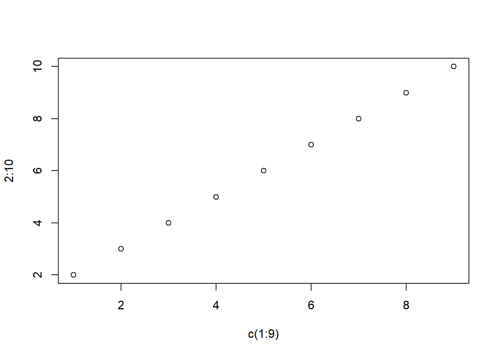

```r
plot(x=c(1:9), y=2:10)
```

### 데이터프레임

```r
data.frame(matrix(c(1:9), nrow=3, byrow=T))
```

```
##   X1 X2 X3
## 1  1  2  3
## 2  4  5  6
## 3  7  8  9
```

### 함수

```r
add <- function(x, y){
  return(x+y)
}
add(1, 2)
```

```
## [1] 3
```

# 객체, 모드 그리고 속성

## 타고난 속성: 모드, 길이

### 숫자: numeric

```r
x <- 1:10
mode(x)
```

```
## [1] "numeric"
```

```r
length(x)
```

```
## [1] 10
```

```r
typeof(x)
```

```
## [1] "integer"
```

```r
x <- c(0.1, 1, 0.3)
mode(x)
```

```
## [1] "numeric"
```

```r
length(x)
```

```
## [1] 3
```

```r
typeof(x)
```

```
## [1] "double"
```

### 복소수: complex

```r
x <- 1+2i
mode(x)
```

```
## [1] "complex"
```

```r
length(x)
```

```
## [1] 1
```

```r
typeof(x)
```

```
## [1] "complex"
```

### 문자: character

```r
y <-"R 기본 개념"
mode(y)
```

```
## [1] "character"
```

```r
length(y)
```

```
## [1] 1
```

### 리스트

```r
z <- list(x, y)
mode(z)
```

```
## [1] "list"
```

```r
length(z)
```

```
## [1] 2
```

```r
# 리스트는 리스트를 품을 수 있음
is.recursive(z)
```

```
## [1] TRUE
```

### 모드의 변경

```r
x <- c(0.1, 1, 0.3)
xtoc <- as.character(x)
print(xtoc)
```

```
## [1] "0.1" "1"   "0.3"
```

```r
mode(xtoc)
```

```
## [1] "character"
```

```r
ctox <- as.integer(xtoc)
print(ctox)
```

```
## [1] 0 1 0
```

```r
mode(ctox)
```

```
## [1] "numeric"
```

## 객체 길이 변경

객체의 길이는 변경 가능하다.

```r
x <- numeric()
print(x)
```

```
## numeric(0)
```

```r
length(x)
```

```
## [1] 0
```

```r
x <- numeric(5)
print(x)
```

```
## [1] 0 0 0 0 0
```

```r
x[10] <- 10
print(x)
```

```
##  [1]  0  0  0  0  0 NA NA NA NA 10
```

```r
x[11] <- 11
print(x)
```

```
##  [1]  0  0  0  0  0 NA NA NA NA 10 11
```

```r
length(x) <- c(5)
print(x)
```

```
## [1] 0 0 0 0 0
```

## 객체 속성의 정의

타고난(intrinsic) 속성 또는 고유 속성(모드와 길이)이 아닌 속성에 대한 정의 및 조회

### 속성 정의

```r
x <- numeric()
length(x) <- 5*5
print(x)
```

```
##  [1] NA NA NA NA NA NA NA NA NA NA NA NA NA NA NA NA NA NA NA NA NA NA NA
## [24] NA NA
```

```r
attr(x, "dim") <- c(5,5)
print(x)
```

```
##      [,1] [,2] [,3] [,4] [,5]
## [1,]   NA   NA   NA   NA   NA
## [2,]   NA   NA   NA   NA   NA
## [3,]   NA   NA   NA   NA   NA
## [4,]   NA   NA   NA   NA   NA
## [5,]   NA   NA   NA   NA   NA
```

### 속성 조회

```r
attr(x, "dim")
```

```
## [1] 5 5
```

```r
dim(x)
```

```
## [1] 5 5
```

```r
nrow(x)
```

```
## [1] 5
```

```r
ncol(x)
```

```
## [1] 5
```

## 객체의 클래스

```r
x <- 1:10
mode(x)
```

```
## [1] "numeric"
```

```r
typeof(x)
```

```
## [1] "integer"
```

```r
class(x)
```

```
## [1] "integer"
```

### 숫자 실수형

```r
x <- c(1.1, 2.1)
mode(x)
```

```
## [1] "numeric"
```

```r
typeof(x)
```

```
## [1] "double"
```

```r
class(x)
```

```
## [1] "numeric"
```

### 문자형

```r
letters
```

```
##  [1] "a" "b" "c" "d" "e" "f" "g" "h" "i" "j" "k" "l" "m" "n" "o" "p" "q"
## [18] "r" "s" "t" "u" "v" "w" "x" "y" "z"
```

```r
mode(letters)
```

```
## [1] "character"
```

```r
typeof(letters)
```

```
## [1] "character"
```

```r
class(letters)
```

```
## [1] "character"
```

### 리스트

```r
x <- list(A=c(1, 2, 3), B=c("ab", "bc", "cd"))
mode(x)
```

```
## [1] "list"
```

```r
typeof(x)
```

```
## [1] "list"
```

```r
class(x)
```

```
## [1] "list"
```

### 데이터프레임

```r
df <- as.data.frame(x)
mode(df)
```

```
## [1] "list"
```

```r
typeof(df)
```

```
## [1] "list"
```

```r
class(df)
```

```
## [1] "data.frame"
```

### 클래스의 제거

```r
udf <- unclass(df)
class(udf)
```

```
## [1] "list"
```

# 순서, 무순서 요인

## 예를 통한 이해

### 숫자 데이터

```r
x <- c(1, 2, 3, 4, 3, 4, 5)
x_fac <- factor(x)
print(x_fac)
```

```
## [1] 1 2 3 4 3 4 5
## Levels: 1 2 3 4 5
```

```r
levels(x_fac)
```

```
## [1] "1" "2" "3" "4" "5"
```

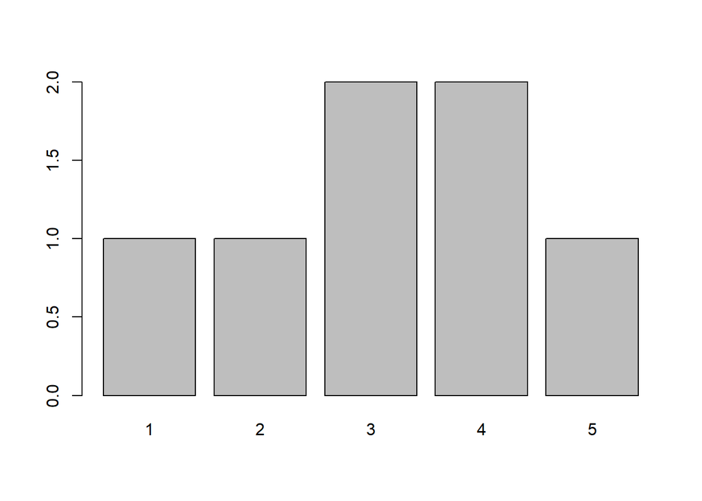

```r
plot(x_fac)
```

### 범주 데이터

호주의 행정구역 데이터

```r
state <- c("tas", "sa", "qld", "nsw", "nsw", "nt", "wa", "wa",
"qld", "vic", "nsw", "vic", "qld", "qld", "sa", "tas",
"sa", "nt", "wa", "vic", "qld", "nsw", "nsw", "wa",
"sa", "act", "nsw", "vic", "vic", "act")
table(state)
```

```
## state
## act nsw  nt qld  sa tas vic  wa
##   2   6   2   5   4   2   5   4
```

값 순서대로 정렬

```r
statef <- factor(state)
print(statef)
```

```
##  [1] tas sa  qld nsw nsw nt  wa  wa  qld vic nsw vic qld qld sa  tas sa
## [18] nt  wa  vic qld nsw nsw wa  sa  act nsw vic vic act
## Levels: act nsw nt qld sa tas vic wa
```

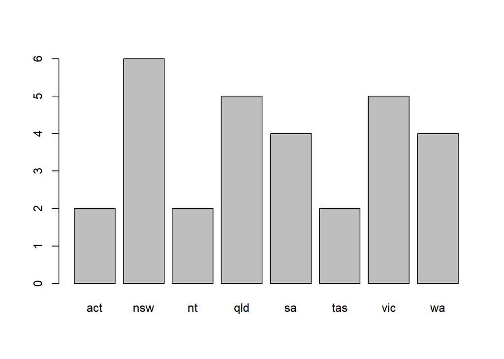

```r
plot(statef)
```

### 요인의 속성

```r
mode(statef) # 고유 속성은 숫자
```

```
## [1] "numeric"
```

```r
length(statef) # 길이는 원래 데이터와 동일
```

```
## [1] 30
```

```r
class(statef)
```

```
## [1] "factor"
```

```r
levels(statef) # 알파벳 순으로 정렬
```

```
## [1] "act" "nsw" "nt"  "qld" "sa"  "tas" "vic" "wa"
```

```r
is.ordered(statef) # 순서가 있는 인자인지 확인
```

```
## [1] FALSE
```

```r
ordered(state) # 순서가 있는 경우
```

```
##  [1] tas sa  qld nsw nsw nt  wa  wa  qld vic nsw vic qld qld sa  tas sa
## [18] nt  wa  vic qld nsw nsw wa  sa  act nsw vic vic act
## Levels: act < nsw < nt < qld < sa < tas < vic < wa
```

### 요인의 활용

tapply(), 비정형 배열(ragged array)

```r
# 인자와 같은 크기의 수입 데이터
incomes <- c(60, 49, 40, 61, 64, 60, 59, 54, 62, 69, 70, 42, 56,
61, 61, 61, 58, 51, 48, 65, 49, 49, 41, 48, 52, 46,
59, 46, 58, 43)
length(statef)
```

```
## [1] 30
```

```r
length(incomes)
```

```
## [1] 30
```

수입 데이터를 인자 별로 분류하고 각 인자 별 평균을 구한다.

```r
incmeans <- tapply(incomes, statef, mean)
print(incmeans, digits=4)
```

```
##   act   nsw    nt   qld    sa   tas   vic    wa
## 44.50 57.33 55.50 53.60 55.00 60.50 56.00 52.25
```

표준편차를 구한다.
$$\sqrt{Var(\bar{x})}=\sqrt{Var(x)\over{n}}$$

```r
stdError <- function(x) sqrt(var(x)/length(x))
incster <- tapply(incomes, statef, stdError)
print(incster, digits=4)
```

```
##   act   nsw    nt   qld    sa   tas   vic    wa
## 1.500 4.310 4.500 4.106 2.739 0.500 5.244 2.658
```

# 배열과 행렬

## 배열 정의

2차원 이상의 데이터를 저장할 수 있는 데이터 객체

```r
x <- seq(1, 24, 1) # 여기까지는 벡터
is.array(x)
```

```
## [1] FALSE
```

```r
dim(x) <- c(24)
is.array(x)
```

```
## [1] TRUE
```

```r
dim(x) <- c(3,8)
print(x) # 열 우선으로 표현
```

```
##      [,1] [,2] [,3] [,4] [,5] [,6] [,7] [,8]
## [1,]    1    4    7   10   13   16   19   22
## [2,]    2    5    8   11   14   17   20   23
## [3,]    3    6    9   12   15   18   21   24
```

```r
dim(x) <- c(2, 4, 3) # 2*4 크기의 배열을 3개 구성
print(x)
```

```
## , , 1
##
##      [,1] [,2] [,3] [,4]
## [1,]    1    3    5    7
## [2,]    2    4    6    8
##
## , , 2
##
##      [,1] [,2] [,3] [,4]
## [1,]    9   11   13   15
## [2,]   10   12   14   16
##
## , , 3
##
##      [,1] [,2] [,3] [,4]
## [1,]   17   19   21   23
## [2,]   18   20   22   24
```

```r
dim(x) <- c(3, 8)
t(x) # 행과 열을 전치하고자 하는 경우
```

```
##      [,1] [,2] [,3]
## [1,]    1    2    3
## [2,]    4    5    6
## [3,]    7    8    9
## [4,]   10   11   12
## [5,]   13   14   15
## [6,]   16   17   18
## [7,]   19   20   21
## [8,]   22   23   24
```

```r
matrix(x, nrow=3, ncol=8, byrow=TRUE)
```

```
##      [,1] [,2] [,3] [,4] [,5] [,6] [,7] [,8]
## [1,]    1    2    3    4    5    6    7    8
## [2,]    9   10   11   12   13   14   15   16
## [3,]   17   18   19   20   21   22   23   24
```

```r
x <- array(x, dim=c(3, 4, 2)) # array 함수 이용
print(x)
```

```
## , , 1
##
##      [,1] [,2] [,3] [,4]
## [1,]    1    4    7   10
## [2,]    2    5    8   11
## [3,]    3    6    9   12
##
## , , 2
##
##      [,1] [,2] [,3] [,4]
## [1,]   13   16   19   22
## [2,]   14   17   20   23
## [3,]   15   18   21   24
```

```r
is.matrix(x)
```

```
## [1] FALSE
```

## 배열 색인, 배열 구획

배열의 원소는 대괄호([]: square bracket) 안에 첨자(subscript)를 이용하여 참조할 수 있다.

```r
x <- 1:12
dim(x) <- c(3, 4)
print(x)
```

```
##      [,1] [,2] [,3] [,4]
## [1,]    1    4    7   10
## [2,]    2    5    8   11
## [3,]    3    6    9   12
```

```r
x[1,2]
```

```
## [1] 4
```

```r
x[1:2,] # 2x4 배열
```

```
##      [,1] [,2] [,3] [,4]
## [1,]    1    4    7   10
## [2,]    2    5    8   11
```

```r
dim(x[1:2,])
```

```
## [1] 2 4
```

```r
x[1,] # 1x4 배열, 벡터
```

```
## [1]  1  4  7 10
```

```r
dim(x[1,]) # 벡터는 차원이 없음
```

```r
is.vector(x[1,])
```

```
## [1] TRUE
```

```r
is.array(x[1,])
```

```
## [1] FALSE
```

## 색인 행렬

```r
x <- array(1:20, dim=c(4,5))
print(x)
```

```
##      [,1] [,2] [,3] [,4] [,5]
## [1,]    1    5    9   13   17
## [2,]    2    6   10   14   18
## [3,]    3    7   11   15   19
## [4,]    4    8   12   16   20
```

```r
i <- array(c(1:3, 3:1), dim=c(3,2)) # 특정 구역 정의
print(i)
```

```
##      [,1] [,2]
## [1,]    1    3
## [2,]    2    2
## [3,]    3    1
```

```r
x[i]
```

```
## [1] 9 6 3
```

```r
x[i] <- 0 # 특정 구역의 값을 바꾸기
print(x)
```

```
##      [,1] [,2] [,3] [,4] [,5]
## [1,]    1    5    0   13   17
## [2,]    2    0   10   14   18
## [3,]    0    7   11   15   19
## [4,]    4    8   12   16   20
```

## 배열 외적

배열의 외적(outer product, cross product)은 두개의 배열의 모든 가능한 조합의 배열이다.

```r
x <- array(1:3)
y <- array(4:6)

x %o% y # 외적
```

```
##      [,1] [,2] [,3]
## [1,]    4    5    6
## [2,]    8   10   12
## [3,]   12   15   18
```

```r
outer(x, y, "*") # 함수 이용
```

```
##      [,1] [,2] [,3]
## [1,]    4    5    6
## [2,]    8   10   12
## [3,]   12   15   18
```

```r
x %*% t(y) # 열 배열과 행 배열의 곱: 외적과 동일
```

```
##      [,1] [,2] [,3]
## [1,]    4    5    6
## [2,]    8   10   12
## [3,]   12   15   18
```

# x, y의 모든 가능한 조합에서의 함수값 구하기

```r
x <- y <- -10:10
# f <- function(x,y) cos(y)/(1+x^2)
f <- function(x, y) return(x^2+y^2)
z <- outer(x, y, f)
print(z[, 1:3], digits=4)
```

```
##       [,1] [,2] [,3]
##  [1,]  200  181  164
##  [2,]  181  162  145
##  [3,]  164  145  128
##  [4,]  149  130  113
##  [5,]  136  117  100
##  [6,]  125  106   89
##  [7,]  116   97   80
##  [8,]  109   90   73
##  [9,]  104   85   68
## [10,]  101   82   65
## [11,]  100   81   64
## [12,]  101   82   65
## [13,]  104   85   68
## [14,]  109   90   73
## [15,]  116   97   80
## [16,]  125  106   89
## [17,]  136  117  100
## [18,]  149  130  113
## [19,]  164  145  128
## [20,]  181  162  145
## [21,]  200  181  164
```

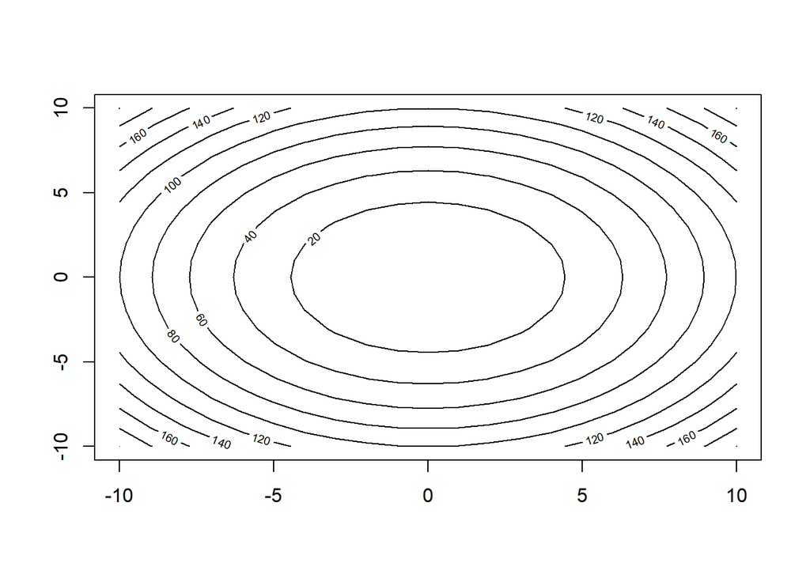

```r
contour(x, y, z)
```

## 배열의 전치

```r
x = array(1:10, dim=c(2,5))
print(x)
```

```
##      [,1] [,2] [,3] [,4] [,5]
## [1,]    1    3    5    7    9
## [2,]    2    4    6    8   10
```

```r
t(x)
```

```
##      [,1] [,2]
## [1,]    1    2
## [2,]    3    4
## [3,]    5    6
## [4,]    7    8
## [5,]    9   10
```

## 행렬 기반의 함수

### 행렬 곱

```r
# 행 우선으로 행렬 생성
A = matrix(1:6, nrow=3, ncol=3, byrow=T)
B = matrix(1:6, nrow=3, ncol=3, byrow=T)
x = 1:3

print(A)
```

```
##      [,1] [,2] [,3]
## [1,]    1    2    3
## [2,]    4    5    6
## [3,]    1    2    3
```

```r
print(B)
```

```
##      [,1] [,2] [,3]
## [1,]    1    2    3
## [2,]    4    5    6
## [3,]    1    2    3
```

```r
print(A * B) # 원소별 곱
```

```
##      [,1] [,2] [,3]
## [1,]    1    4    9
## [2,]   16   25   36
## [3,]    1    4    9
```

```r
print(A %*% B) # 행렬 곱
```

```
##      [,1] [,2] [,3]
## [1,]   12   18   24
## [2,]   30   45   60
## [3,]   12   18   24
```

```r
t(x) %*% A %*% x
```

```
##      [,1]
## [1,]  120
```

```r
diag(1:3) #  벡터의 값을 대각 원소의 값으로 갖는 행렬 출력
```

```
##      [,1] [,2] [,3]
## [1,]    1    0    0
## [2,]    0    2    0
## [3,]    0    0    3
```

```r
diag(A) # 기존 행렬의 대각 원소의 값을 벡터로 출력
```

```
## [1] 1 5 3
```

```r
is.vector(diag(A))
```

```
## [1] TRUE
```

### 선형 방정식과 역 행렬

$$Ax=b \Rightarrow x=A^{-1}b$$

```r
A <-  matrix(c(1,3,2, 2, 4, 5, 6, 4,3), nrow=3)
b <- array(c(3, 2, 2))

# A의 역행렬 구한 후 값 구하기: 수치적으로 비효율적이며 불안정함
A_inverse=solve(A)
solve(A) %*% b
```

```
##          [,1]
## [1,] -0.25000
## [2,]  0.21875
## [3,]  0.46875
```

```r
# 추천 방식: 직접 선형 방정식을 입력
solve(A, b)
```

```
## [1] -0.25000  0.21875  0.46875
```

### 고유값과 고유벡터

$$Ax = \lambda x, x: eigenvector, \lambda: eigenvalue$$

```r
# 대칭(symmetric) 행렬 구성
B <-  matrix(c(1, 3, 2, 2, 4, 5, 6, 4, 3), nrow=3)
A <- t(B) %*% B

# 고유값, 고유벡터 계산
ev <- eigen(A)
print(ev)
```

```
## eigen() decomposition
## $values
## [1] 108.7997110  10.2852090   0.9150801
##
## $vectors
##            [,1]       [,2]       [,3]
## [1,] -0.3361017 -0.3095407  0.8895056
## [2,] -0.6100498 -0.6479954 -0.4560058
## [3,] -0.7175479  0.6959070 -0.0289571
```

```r
mode(ev) # 고유 속성은 리스트
```

```
## [1] "list"
```

```r
# 고유값을 가져오기 위한 방법
ev$values # 고유값
```

```
## [1] 108.7997110  10.2852090   0.9150801
```

```r
ev["values"]
```

```
## $values
## [1] 108.7997110  10.2852090   0.9150801
```

```r
# 고유벡터
ev$vectors
```

```
##            [,1]       [,2]       [,3]
## [1,] -0.3361017 -0.3095407  0.8895056
## [2,] -0.6100498 -0.6479954 -0.4560058
## [3,] -0.7175479  0.6959070 -0.0289571
```

```r
# 확인: 1번째 고유값과 고유벡터
print(A %*% ev$vectors[,1])
```

```
##           [,1]
## [1,] -36.56777
## [2,] -66.37324
## [3,] -78.06900
```

```r
print(ev$values[1]*ev$vectors[,1])
```

```
## [1] -36.56777 -66.37324 -78.06900
```

### 특이값 분해 및 행렬식

$$A_{n\times p} = U_{n\times r}D_{r\times r}V^T_{r\times p},\\ U, V: orthogonal \enspace matrix \\D: diagonal \enspace matrix$$

```r
# 행렬 생성
A <-  matrix(c(1,3,2, 2, 4, 5, 6, 4,3, 10), nrow=2)
print(A)
```

```
##      [,1] [,2] [,3] [,4] [,5]
## [1,]    1    2    4    6    3
## [2,]    3    2    5    4   10
```

```r
dim(A)
```

```
## [1] 2 5
```

```r
# 특이값 분해
svd <- svd(A)
print(svd)
```

```
## $d
## [1] 14.218972  4.221472
##
## $u
##            [,1]       [,2]
## [1,] -0.5112087 -0.8594566
## [2,] -0.8594566  0.5112087
##
## $v
##            [,1]       [,2]
## [1,] -0.2172856  0.1597001
## [2,] -0.1927939 -0.1649888
## [3,] -0.4460321 -0.2088804
## [4,] -0.4574929 -0.7371610
## [5,] -0.7123013  0.6001977
```

```r
# 원 행렬과 같은지 확인
svd$u %*% diag(svd$d) %*% t(svd$v)
```

```
##      [,1] [,2] [,3] [,4] [,5]
## [1,]    1    2    4    6    3
## [2,]    3    2    5    4   10
```

```r
# 정방행렬 생성
B <- t(A) %*% A
det(B)
```

```
## [1] -1.72675e-42
```

### 최소제곱 적합, QR 분해

$$Least\enspace Squares\enspace Fitting: min_{\beta} (y-X\beta)^T(y-X\beta) \\
normal \enspace equation: X^TX=X^Ty \\
QR \enspace decompostion: X^TX=QR , \\
Q: orthogonal \enspace matrix, R: upper \enspace triangular \enspace matrix$$

```r
# X, y 생성
X <-  matrix(c(1,3,2, 2, 2, 5, 6, 4,3, 10), nrow=5)
y <- rnorm(5, 0, 1)

# 최소제곱 적합
fit <- lsfit(X, y, intercept = T)
print(fit)
```

```
## $coefficients
##  Intercept         X1         X2
##  0.6313620 -0.1013951 -0.1172900
##
## $residuals
## [1]  0.2197826  0.2197826 -0.2072024 -0.1049756 -0.1273872
##
## $intercept
## [1] TRUE
##
## $qr
## $qt
## [1]  0.51038798  0.22633095 -0.62835058 -0.08189507 -0.40010275
##
## $qr
##       Intercept        X1          X2
## [1,] -2.2360680 -4.472136 -12.5219807
## [2,]  0.4472136 -1.414214  -0.7071068
## [3,]  0.4472136  0.218508   5.3572381
## [4,]  0.4472136  0.218508   0.4780929
## [5,]  0.4472136  0.218508  -0.8285506
##
## $qraux
## [1] 1.447214 1.925615 1.291430
##
## $rank
## [1] 3
##
## $pivot
## [1] 1 2 3
##
## $tol
## [1] 1e-07
##
## attr(,"class")
## [1] "qr"
```

```r
# 회귀계수
fit$coef
```

```
##  Intercept         X1         X2
##  0.6313620 -0.1013951 -0.1172900
```

```r
# QR 분해에 의한 회귀직선 적합: 절편항을 추가 후 적합
X_plus_ones = cbind(array(1, dim=c(5,1)), X)
qr <- qr(X_plus_ones, y)
print(qr$qr)
```

```
##            [,1]      [,2]        [,3]
## [1,] -2.2360680 -4.472136 -12.5219807
## [2,]  0.4472136 -1.414214  -0.7071068
## [3,]  0.4472136  0.218508   5.3572381
## [4,]  0.4472136  0.218508   0.4780929
## [5,]  0.4472136  0.218508  -0.8285506
```

```r
# Q & R
Q = qr.Q(qr)
R = qr.R(qr)
print(Q)
```

```
##            [,1]          [,2]        [,3]
## [1,] -0.4472136  7.071068e-01 -0.01866633
## [2,] -0.4472136 -7.071068e-01 -0.01866633
## [3,] -0.4472136 -2.775558e-17 -0.29866136
## [4,] -0.4472136 -2.775558e-17 -0.48532471
## [5,] -0.4472136 -2.775558e-17  0.82131873
```

```r
print(R)
```

```
##           [,1]      [,2]        [,3]
## [1,] -2.236068 -4.472136 -12.5219807
## [2,]  0.000000 -1.414214  -0.7071068
## [3,]  0.000000  0.000000   5.3572381
```

```r
# 확인
Q %*% R
```

```
##      [,1] [,2] [,3]
## [1,]    1    1    5
## [2,]    1    3    6
## [3,]    1    2    4
## [4,]    1    2    3
## [5,]    1    2   10
```

```r
# 회귀계수
qr.coef(qr, y)
```

```
## [1]  0.6313620 -0.1013951 -0.1172900
```

## 분할 행렬 구성(partitioned matrix)

벡터나 행렬로부터 새로운 행렬을 구성하는 것을 의미한다.

```r
# 행렬 구성
X <-  matrix(c(1, 3, 2, 2, 2, 5, 6, 4, 3, 10), nrow=5)
print(X)
```

```
##      [,1] [,2]
## [1,]    1    5
## [2,]    3    6
## [3,]    2    4
## [4,]    2    3
## [5,]    2   10
```

```r
cy <- rnorm(5, 0, 1)
ry <- runif(2)

# 열 별 결합
XwithCY <- cbind(X, cy)
print(XwithCY)
```

```
##                   cy
## [1,] 1  5 -0.2331327
## [2,] 3  6  0.7232911
## [3,] 2  4  2.0979085
## [4,] 2  3  0.6580700
## [5,] 2 10  1.9517256
```

```r
is.matrix(XwithCY)
```

```
## [1] TRUE
```

```r
# 행 별 결합
XbelowRY <- rbind(X, ry)
print(XwithCY)
```

```
##                   cy
## [1,] 1  5 -0.2331327
## [2,] 3  6  0.7232911
## [3,] 2  4  2.0979085
## [4,] 2  3  0.6580700
## [5,] 2 10  1.9517256
```

```r
# 자동 차원 조절
cbind(1, X)
```

```
##      [,1] [,2] [,3]
## [1,]    1    1    5
## [2,]    1    3    6
## [3,]    1    2    4
## [4,]    1    2    3
## [5,]    1    2   10
```

```r
rbind(1, X)
```

```
##      [,1] [,2]
## [1,]    1    1
## [2,]    1    5
## [3,]    3    6
## [4,]    2    4
## [5,]    2    3
## [6,]    2   10
```

## 연결 함수

c 함수는 차원을 없애고 연결한다.

```r
# 행렬 생성
X <-  matrix(c(1, 3, 2, 2, 2, 5, 6, 4, 3, 10), nrow=2)
print(X)
```

```
##      [,1] [,2] [,3] [,4] [,5]
## [1,]    1    2    2    6    3
## [2,]    3    2    5    4   10
```

```r
as.vector(X) # 열 우선으로 벡터를 구성
```

```
##  [1]  1  3  2  2  2  5  6  4  3 10
```

```r
# 연결함수 적용
c(X, X)
```

```
##  [1]  1  3  2  2  2  5  6  4  3 10  1  3  2  2  2  5  6  4  3 10
```

```r
is.matrix(c(X, X))
```

```
## [1] FALSE
```

## 요인벡터를 이용한 빈도표 생성

```r
# 범주 데이터 구성
state <- c("tas", "sa", "qld", "nsw", "nsw", "nt", "wa", "wa",
"qld", "vic", "nsw", "vic", "qld", "qld", "sa", "tas",
"sa", "nt", "wa", "vic", "qld", "nsw", "nsw", "wa",
"sa", "act", "nsw", "vic", "vic", "act")

# 원 데이터로 부터 빈도표 구성
table(state)
```

```
## state
## act nsw  nt qld  sa tas vic  wa
##   2   6   2   5   4   2   5   4
```

```r
# 인자 생성
statef <- factor(state)
# 인자로부터 빈도표 구성
table(statef)
```

```
## statef
## act nsw  nt qld  sa tas vic  wa
##   2   6   2   5   4   2   5   4
```

```r
# 숫자 데이터 구성: 인자와 같은 크기로 구성
income <- runif(length(state), 10, 100)

# 데이터 값의 4분위수에 해당 하는 값을 구성(버킷 구성): 범주 변수로 재탄생
incomecut <- cut(income, breaks=quantile(income, probs=seq(0,1, 0.25)), include.lowest=T)
print(incomecut)
```

```
##  [1] (22.6,51.1] (22.6,51.1] [11.4,22.6] (75.5,99]   [11.4,22.6]
##  [6] (75.5,99]   (75.5,99]   (22.6,51.1] [11.4,22.6] (51.1,75.5]
## [11] (22.6,51.1] (51.1,75.5] (51.1,75.5] (51.1,75.5] (22.6,51.1]
## [16] (75.5,99]   [11.4,22.6] [11.4,22.6] (51.1,75.5] (75.5,99]
## [21] (75.5,99]   (75.5,99]   (22.6,51.1] (51.1,75.5] [11.4,22.6]
## [26] (22.6,51.1] [11.4,22.6] (51.1,75.5] (75.5,99]   [11.4,22.6]
## Levels: [11.4,22.6] (22.6,51.1] (51.1,75.5] (75.5,99]
```

```r
# 빈도표 구성
incomef <- factor(incomecut)
table(incomef) # 빈도가 비슷
```

```
## incomef
## [11.4,22.6] (22.6,51.1] (51.1,75.5]   (75.5,99]
##           8           7           7           8
```

```r
# 2원 빈도표 구성
table(statef, incomef)
```

```
##       incomef
## statef [11.4,22.6] (22.6,51.1] (51.1,75.5] (75.5,99]
##    act           1           1           0         0
##    nsw           2           2           0         2
##    nt            1           0           0         1
##    qld           2           0           2         1
##    sa            2           2           0         0
##    tas           0           1           0         1
##    vic           0           0           3         2
##    wa            0           1           2         1
```

```r
# 원 데이터로부터 구성: 범주 변수인 경우는 동일
table(state, incomef)
```

```
##      incomef
## state [11.4,22.6] (22.6,51.1] (51.1,75.5] (75.5,99]
##   act           1           1           0         0
##   nsw           2           2           0         2
##   nt            1           0           0         1
##   qld           2           0           2         1
##   sa            2           2           0         0
##   tas           0           1           0         1
##   vic           0           0           3         2
##   wa            0           1           2         1
```

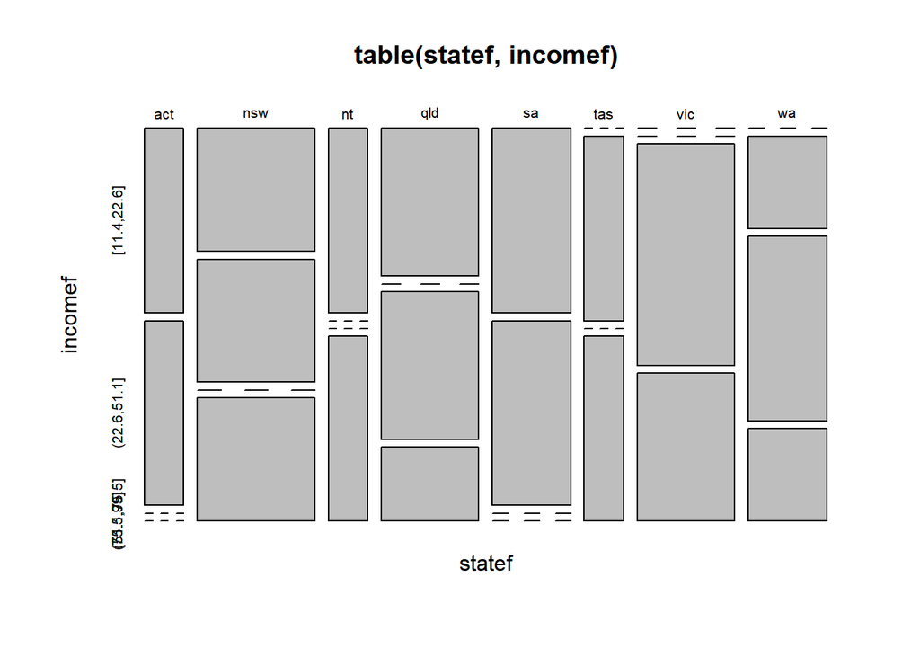

```r
# 그림으로 확인
plot(table(statef, incomef))
```

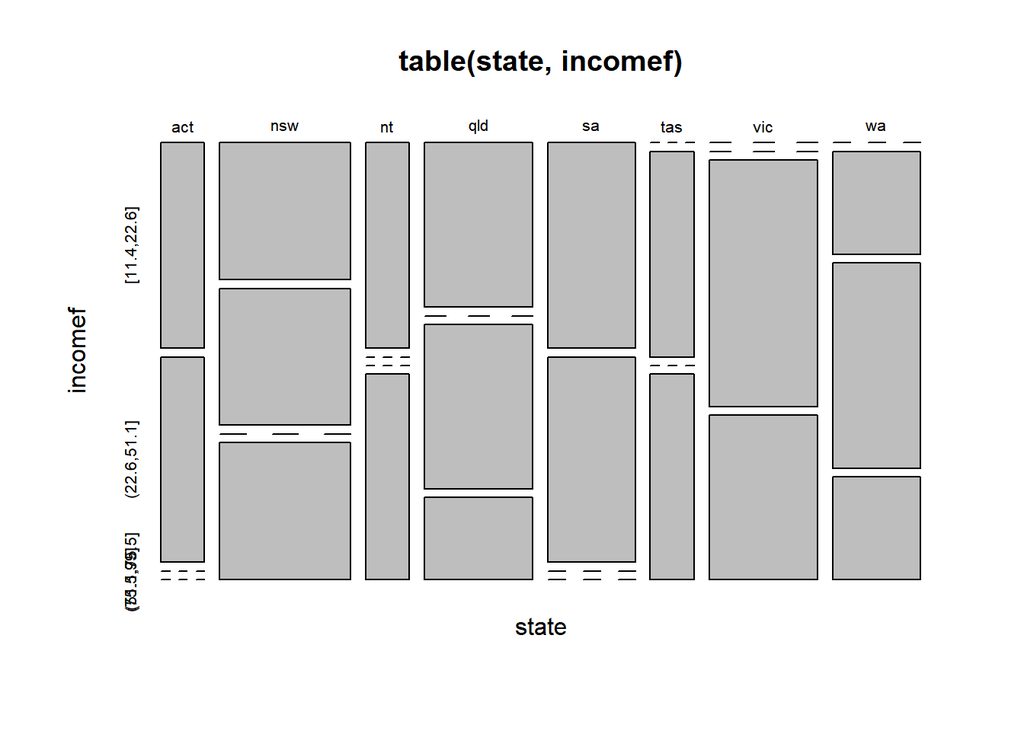

```r
plot(table(state, incomef))
```

# 리스트와 데이터프레임

## 리스트

리스트(list)는 객체들을 순서대로 모아 놓은 모임이다. 각 객체들은 구성원(component)이라 한다.

```r
# 구성원 생성
x <- c(1:10)
y <- matrix(seq(1,6), nrow=2)
z <- 'R 기반의 통계분석'

# 리스트 생성 및 구성원에 대한 이름 주기
lst <- list(x=x, y=y, z=z)
print(lst)
```

```
## $x
##  [1]  1  2  3  4  5  6  7  8  9 10
##
## $y
##      [,1] [,2] [,3]
## [1,]    1    3    5
## [2,]    2    4    6
##
## $z
## [1] "R 기반의 통계분석"
```

```r
names(lst)
```

```
## [1] "x" "y" "z"
```

```r
# lst <- list(x, y, z)
# print(lst)
# names(lst)

# 이름으로 구성원 가져오기
lst$x
```

```
##  [1]  1  2  3  4  5  6  7  8  9 10
```

```r
# 색인으로 구성원 가져오기
lst[[3]]
```

```
## [1] "R 기반의 통계분석"
```

```r
lst[3]
```

```
## $z
## [1] "R 기반의 통계분석"
```

```r
# 구성원에서 특정 위치 값 가져오기
lst[[1]][1]
```

```
## [1] 1
```

```r
lst[[2]][1,2]
```

```
## [1] 3
```

### 리스트 수정, 리스트 연결

```r
# 구성원 생성
x <- c(1:10)
y <- matrix(seq(1,6), nrow=2)

# 리스트 생성
lst <- list(x=x, y=y)
print(lst)
```

```
## $x
##  [1]  1  2  3  4  5  6  7  8  9 10
##
## $y
##      [,1] [,2] [,3]
## [1,]    1    3    5
## [2,]    2    4    6
```

```r
# 리스트 수정
lst[[2]] <- matrix(seq(1,6), nrow=3)
lst$y <- matrix(seq(1,6), nrow=3)
print(lst)
```

```
## $x
##  [1]  1  2  3  4  5  6  7  8  9 10
##
## $y
##      [,1] [,2]
## [1,]    1    4
## [2,]    2    5
## [3,]    3    6
```

```r
# 리스트 연결
clist <- c(lst, lst)
mode(clist)
```

```
## [1] "list"
```

## 데이터프레임

### 데이터프레임 생성

```r
# 태그 없는 데이터프레임
df <- data.frame(rnorm(100), runif(100), sample(c('A','B', 'C', 'D'), 100, replace=T))
str(df)
```

```
## 'data.frame':    100 obs. of  3 variables:
##  $ rnorm.100.                                     : num  0.126 -0.551 0.499 -1.959 0.729 ...
##  $ runif.100.                                     : num  0.772 0.712 0.334 0.762 0.694 ...
##  $ sample.c..A....B....C....D....100..replace...T.: Factor w/ 4 levels "A","B","C","D": 2 2 2 1 2 2 2 2 1 3 ...
```

```r
# 태그 있는 데이터프레임
df <- data.frame(a=rnorm(100), b=runif(100), c=sample(c('A','B', 'C', 'D'), 100, replace=T))
str(df)
```

```
## 'data.frame':    100 obs. of  3 variables:
##  $ a: num  1.175 -0.553 -1.087 -1.182 -1.516 ...
##  $ b: num  0.40594 0.00731 0.50324 0.223 0.97114 ...
##  $ c: Factor w/ 4 levels "A","B","C","D": 3 3 1 3 3 4 2 1 4 1 ...
```

```r
mode(df)
```

```
## [1] "list"
```

```r
# 각 구성원은 참조하는 방법은 리스트와 동일. 각 구성원도 데이터프레임
df["a"][1:5,]
```

```
## [1]  1.1745647 -0.5533396 -1.0874424 -1.1823762 -1.5156634
```

```r
df[1:5, 'a']
```

```
## [1]  1.1745647 -0.5533396 -1.0874424 -1.1823762 -1.5156634
```

### attach(), detach()

```r
# 데이터프레임 생성
df <- data.frame(a=rnorm(10), b=runif(10), c=sample(c('A','B', 'C', 'D'), 10, replace=T))
# 탐색 경로
search()
```

```
## [1] ".GlobalEnv"        "package:stats"     "package:graphics"
## [4] "package:grDevices" "package:utils"     "package:datasets"
## [7] "package:methods"   "Autoloads"         "package:base"
```

```r
# 탐색 경로에 있는 객체이름 목록
# ls(.GlobalEnv, )

# 탐색 경로 2번째에 올리기
attach(df)
search()
```

```
##  [1] ".GlobalEnv"        "df"                "package:stats"
##  [4] "package:graphics"  "package:grDevices" "package:utils"
##  [7] "package:datasets"  "package:methods"   "Autoloads"
## [10] "package:base"
```

```r
# 객체의 목록 보기
ls(df)
```

```
## [1] "a" "b" "c"
```

```r
# 탐색 경로 위치로 검색
ls(2)
```

```
## [1] "a" "b" "c"
```

```r
# 구성원 이름 확인 및 내용 보기
print(a)
```

```
##  [1] -1.5979689  1.3953920  0.3443404  0.1413850  0.2901735  0.2964116
##  [7] -0.6319631 -1.1580131 -0.2243657 -1.1046623
```

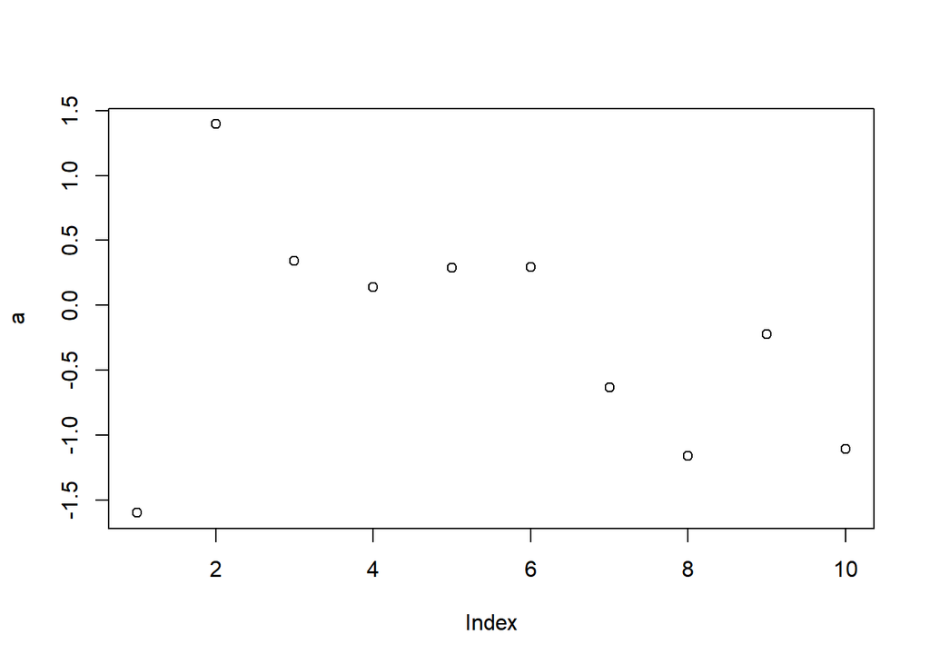

```r
plot(a)
```

```r
# 탐색 경로에서 해제하기
detach(df)
```

### 파일로부터 데이터 읽기

URL로부터 데이터 읽기

```r
df <- read.table("https://archive.ics.uci.edu/ml/machine-learning-databases/housing/housing.data")

# 디폴트 변수명
names(df)
```

```
##  [1] "V1"  "V2"  "V3"  "V4"  "V5"  "V6"  "V7"  "V8"  "V9"  "V10" "V11"
## [12] "V12" "V13" "V14"
```

```r
# 변수명 새로 주기
names(df) <- c("CRIM","ZN","INDUS","CHAS","NOX","RM","AGE","DIS","RAD","TAX","PTRATIO","B","LSTAT","MEDV")

# 데이터 구조 탐색
str(df)
```

```
## 'data.frame':    506 obs. of  14 variables:
##  $ CRIM   : num  0.00632 0.02731 0.02729 0.03237 0.06905 ...
##  $ ZN     : num  18 0 0 0 0 0 12.5 12.5 12.5 12.5 ...
##  $ INDUS  : num  2.31 7.07 7.07 2.18 2.18 2.18 7.87 7.87 7.87 7.87 ...
##  $ CHAS   : int  0 0 0 0 0 0 0 0 0 0 ...
##  $ NOX    : num  0.538 0.469 0.469 0.458 0.458 0.458 0.524 0.524 0.524 0.524 ...
##  $ RM     : num  6.58 6.42 7.18 7 7.15 ...
##  $ AGE    : num  65.2 78.9 61.1 45.8 54.2 58.7 66.6 96.1 100 85.9 ...
##  $ DIS    : num  4.09 4.97 4.97 6.06 6.06 ...
##  $ RAD    : int  1 2 2 3 3 3 5 5 5 5 ...
##  $ TAX    : num  296 242 242 222 222 222 311 311 311 311 ...
##  $ PTRATIO: num  15.3 17.8 17.8 18.7 18.7 18.7 15.2 15.2 15.2 15.2 ...
##  $ B      : num  397 397 393 395 397 ...
##  $ LSTAT  : num  4.98 9.14 4.03 2.94 5.33 ...
##  $ MEDV   : num  24 21.6 34.7 33.4 36.2 28.7 22.9 27.1 16.5 18.9 ...
```

```r
# dim(df)
# nrow(df)
# ncol(df)

# 데이터 내용 보기
head(df)
```

```
##      CRIM ZN INDUS CHAS   NOX    RM  AGE    DIS RAD TAX PTRATIO      B
## 1 0.00632 18  2.31    0 0.538 6.575 65.2 4.0900   1 296    15.3 396.90
## 2 0.02731  0  7.07    0 0.469 6.421 78.9 4.9671   2 242    17.8 396.90
## 3 0.02729  0  7.07    0 0.469 7.185 61.1 4.9671   2 242    17.8 392.83
## 4 0.03237  0  2.18    0 0.458 6.998 45.8 6.0622   3 222    18.7 394.63
## 5 0.06905  0  2.18    0 0.458 7.147 54.2 6.0622   3 222    18.7 396.90
## 6 0.02985  0  2.18    0 0.458 6.430 58.7 6.0622   3 222    18.7 394.12
##   LSTAT MEDV
## 1  4.98 24.0
## 2  9.14 21.6
## 3  4.03 34.7
## 4  2.94 33.4
## 5  5.33 36.2
## 6  5.21 28.7
```

```r
tail(df)
```

```
##        CRIM ZN INDUS CHAS   NOX    RM  AGE    DIS RAD TAX PTRATIO      B
## 501 0.22438  0  9.69    0 0.585 6.027 79.7 2.4982   6 391    19.2 396.90
## 502 0.06263  0 11.93    0 0.573 6.593 69.1 2.4786   1 273    21.0 391.99
## 503 0.04527  0 11.93    0 0.573 6.120 76.7 2.2875   1 273    21.0 396.90
## 504 0.06076  0 11.93    0 0.573 6.976 91.0 2.1675   1 273    21.0 396.90
## 505 0.10959  0 11.93    0 0.573 6.794 89.3 2.3889   1 273    21.0 393.45
## 506 0.04741  0 11.93    0 0.573 6.030 80.8 2.5050   1 273    21.0 396.90
##     LSTAT MEDV
## 501 14.33 16.8
## 502  9.67 22.4
## 503  9.08 20.6
## 504  5.64 23.9
## 505  6.48 22.0
## 506  7.88 11.9
```

하나의 긴 배열로 데이터 읽기

```r
dataArray  <- scan("https://archive.ics.uci.edu/ml/machine-learning-databases/housing/housing.data")
dataArray[1:20]
```

```
##  [1]   0.00632  18.00000   2.31000   0.00000   0.53800   6.57500  65.20000
##  [8]   4.09000   1.00000 296.00000  15.30000 396.90000   4.98000  24.00000
## [15]   0.02731   0.00000   7.07000   0.00000   0.46900   6.42100
```

```r
# 데이터 모양 정하고 데이터 프레임 생성하기
dim(dataArray) <- c(506, 14)
df <- as.data.frame(dataArray)

# 데이터 구조 탐색
str(df)
```

```
## 'data.frame':    506 obs. of  14 variables:
##  $ V1 : num  0.00632 18 2.31 0 0.538 ...
##  $ V2 : num  5.96 0 0.499 5.841 61.4 ...
##  $ V3 : num  0.413 6.065 7.8 5.287 4 ...
##  $ V4 : num  97.1 2.43 5 384 20.9 ...
##  $ V5 : num  5 403 14.7 396.9 29.3 ...
##  $ V6 : num  17.8 395.56 7.56 39.8 0.0689 ...
##  $ V7 : num  13.51 23.3 0.0701 0 13.89 ...
##  $ V8 : num  0.369 22 5.86 0 0.431 ...
##  $ V9 : num  5.32 0 0.405 6.565 22.9 ...
##  $ V10: num  0.493 6.431 14.7 5.416 5 ...
##  $ V11: num  91.1 2.3 24 666 20.2 ...
##  $ V12: num  24 666 20.2 393.1 19.9 ...
##  $ V13: num  20.2 100.2 16.2 14.3 13.9 ...
##  $ V14: num  14.76 20.1 4.35 0 18.1 ...
```

```r
class(df)
```

```
## [1] "data.frame"
```

.csv 파일 읽기

```r
data_path <- c('C:\\banene03\\R\\KM\\Data')
df <- read.table(paste0(data_path, '/bank.csv'), sep=',', header=T)
# df <- read.csv(paste0(data_path, '/bank.csv'))
str(df)
```

```
## 'data.frame':    4521 obs. of  17 variables:
##  $ age      : int  30 33 35 30 59 35 36 39 41 43 ...
##  $ job      : Factor w/ 12 levels "admin.","blue-collar",..: 11 8 5 5 2 5 7 10 3 8 ...
##  $ marital  : Factor w/ 3 levels "divorced","married",..: 2 2 3 2 2 3 2 2 2 2 ...
##  $ education: Factor w/ 4 levels "primary","secondary",..: 1 2 3 3 2 3 3 2 3 1 ...
##  $ default  : Factor w/ 2 levels "no","yes": 1 1 1 1 1 1 1 1 1 1 ...
##  $ balance  : int  1787 4789 1350 1476 0 747 307 147 221 -88 ...
##  $ housing  : Factor w/ 2 levels "no","yes": 1 2 2 2 2 1 2 2 2 2 ...
##  $ loan     : Factor w/ 2 levels "no","yes": 1 2 1 2 1 1 1 1 1 2 ...
##  $ contact  : Factor w/ 3 levels "cellular","telephone",..: 1 1 1 3 3 1 1 1 3 1 ...
##  $ day      : int  19 11 16 3 5 23 14 6 14 17 ...
##  $ month    : Factor w/ 12 levels "apr","aug","dec",..: 11 9 1 7 9 4 9 9 9 1 ...
##  $ duration : int  79 220 185 199 226 141 341 151 57 313 ...
##  $ campaign : int  1 1 1 4 1 2 1 2 2 1 ...
##  $ pdays    : int  -1 339 330 -1 -1 176 330 -1 -1 147 ...
##  $ previous : int  0 4 1 0 0 3 2 0 0 2 ...
##  $ poutcome : Factor w/ 4 levels "failure","other",..: 4 1 1 4 4 1 2 4 4 1 ...
##  $ y        : Factor w/ 2 levels "no","yes": 1 1 1 1 1 1 1 1 1 1 ...
```

```r
# summary(df)
```

### 내장된 데이터 읽기

```r
# datasets 패키지에 내장된 데이터 목록
dlist <- data(package='datasets')

# 리스트의 구조
str(dlist)
```

```
## List of 4
##  $ title  : chr "Data sets"
##  $ header : NULL
##  $ results: chr [1:104, 1:4] "datasets" "datasets" "datasets" "datasets" ...
##   ..- attr(*, "dimnames")=List of 2
##   .. ..$ : NULL
##   .. ..$ : chr [1:4] "Package" "LibPath" "Item" "Title"
##  $ footer : NULL
##  - attr(*, "class")= chr "packageIQR"
```

```r
# 데이터목록 5개만 출력
head(dlist$results, 5)
```

```
##      Package    LibPath
## [1,] "datasets" "C:/Program Files/R/R-3.5.3/library"
## [2,] "datasets" "C:/Program Files/R/R-3.5.3/library"
## [3,] "datasets" "C:/Program Files/R/R-3.5.3/library"
## [4,] "datasets" "C:/Program Files/R/R-3.5.3/library"
## [5,] "datasets" "C:/Program Files/R/R-3.5.3/library"
##      Item
## [1,] "AirPassengers"
## [2,] "BJsales"
## [3,] "BJsales.lead (BJsales)"
## [4,] "BOD"
## [5,] "CO2"
##      Title
## [1,] "Monthly Airline Passenger Numbers 1949-1960"
## [2,] "Sales Data with Leading Indicator"
## [3,] "Sales Data with Leading Indicator"
## [4,] "Biochemical Oxygen Demand"
## [5,] "Carbon Dioxide Uptake in Grass Plants"
```

```r
# 데이터 바로 이용하기
str(BJsales)
```

```
##  Time-Series [1:150] from 1 to 150: 200 200 199 199 199 ...
```

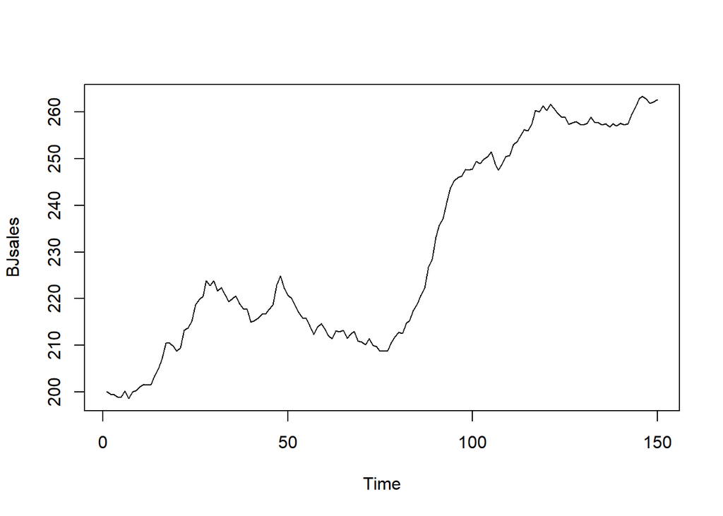

```r
plot(BJsales)
```

```r
str(iris)
```

```
## 'data.frame':    150 obs. of  5 variables:
##  $ Sepal.Length: num  5.1 4.9 4.7 4.6 5 5.4 4.6 5 4.4 4.9 ...
##  $ Sepal.Width : num  3.5 3 3.2 3.1 3.6 3.9 3.4 3.4 2.9 3.1 ...
##  $ Petal.Length: num  1.4 1.4 1.3 1.5 1.4 1.7 1.4 1.5 1.4 1.5 ...
##  $ Petal.Width : num  0.2 0.2 0.2 0.2 0.2 0.4 0.3 0.2 0.2 0.1 ...
##  $ Species     : Factor w/ 3 levels "setosa","versicolor",..: 1 1 1 1 1 1 1 1 1 1 ...
```

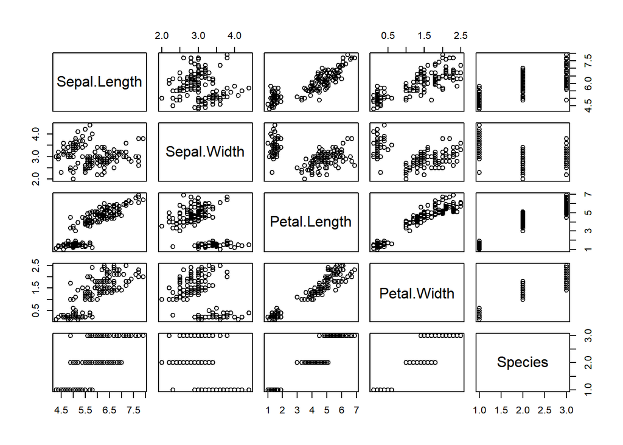

```r
plot(iris)
```

다른 패키지에서 제공되는 데이터 목록 확인 및 로딩

```r
library(ISLR)
head(data(package='ISLR')$results, 5)
```

```
##      Package LibPath                                       Item
## [1,] "ISLR"  "C:/Users/banene/Documents/R/win-library/3.5" "Auto"
## [2,] "ISLR"  "C:/Users/banene/Documents/R/win-library/3.5" "Caravan"
## [3,] "ISLR"  "C:/Users/banene/Documents/R/win-library/3.5" "Carseats"
## [4,] "ISLR"  "C:/Users/banene/Documents/R/win-library/3.5" "College"
## [5,] "ISLR"  "C:/Users/banene/Documents/R/win-library/3.5" "Credit"
##      Title
## [1,] "Auto Data Set"
## [2,] "The Insurance Company (TIC) Benchmark"
## [3,] "Sales of Child Car Seats"
## [4,] "U.S. News and World Report's College Data"
## [5,] "Credit Card Balance Data"
```

```r
# 데이터 바로 이용하기
names(Auto)
```

```
## [1] "mpg"          "cylinders"    "displacement" "horsepower"
## [5] "weight"       "acceleration" "year"         "origin"
## [9] "name"
```

# 확률 분포

## 통계표

표준정규분포: 평균 0, 표준편차 1
$$density \enspace function: \enspace f(x) = {1 \over {\sqrt{2\pi}}} e^{-x^2 \over 2} \\
distribution \enspace function: \enspace P(X \le x)=\int_{-\infty}^{x} f(x)dx$$

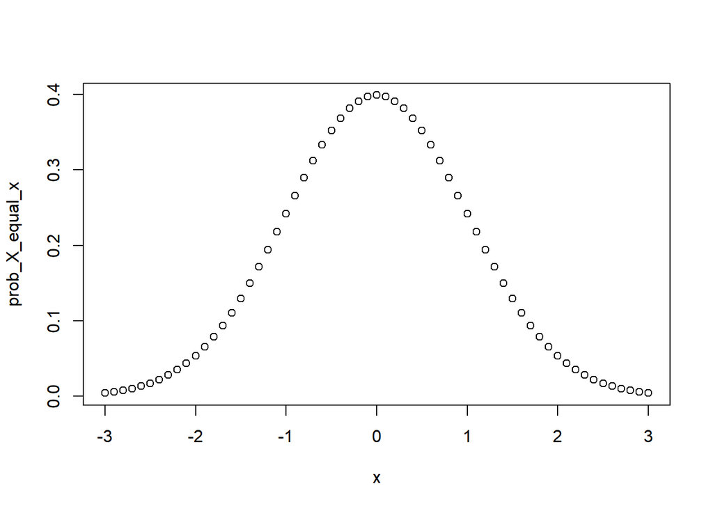

```r
x <- seq(-3, 3, 0.1)

# 확률밀도함수
prob_X_equal_x <-dnorm(x, mean=0, sd=1)
plot(x, prob_X_equal_x)
```

```r
# 분포함수
prob_X_le_x <- pnorm(x, 0,1)
plot(x, prob_X_le_x)

# 분위수함수
qnorm(seq(0,1, 0.05))
```

[output not shown]

```
##  [1]       -Inf -1.6448536 -1.2815516 -1.0364334 -0.8416212 -0.6744898
##  [7] -0.5244005 -0.3853205 -0.2533471 -0.1256613  0.0000000  0.1256613
## [13]  0.2533471  0.3853205  0.5244005  0.6744898  0.8416212  1.0364334
## [19]  1.2815516  1.6448536        Inf
```

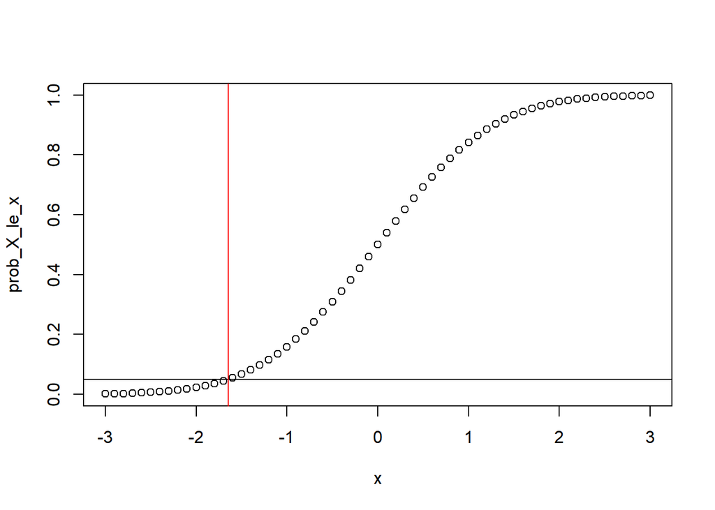

```r
x_where_prob_X_le_0.05 <- qnorm(0.05)

plot(x, prob_X_le_x)
abline(h=0.05)
abline(v=x_where_prob_X_le_0.05, col='red')
```

```r
# 상위 2.5% 에 해당하는 분위수 찾기
qnorm(1-0.025)
```

```
## [1] 1.959964
```

```r
# 상위 0.5% 에 해당하는 분위수 찾기
qnorm(1-0.005)
```

```
## [1] 2.575829
```

```r
# 난수 생성
set.seed(123456789)
rnorm(5, 0, 1)
```

```
## [1]  0.5048723  0.3958758  1.4155378 -0.7223243 -0.6183570
```

t 분포: 정규분포보다 꼬리가 두꺼움

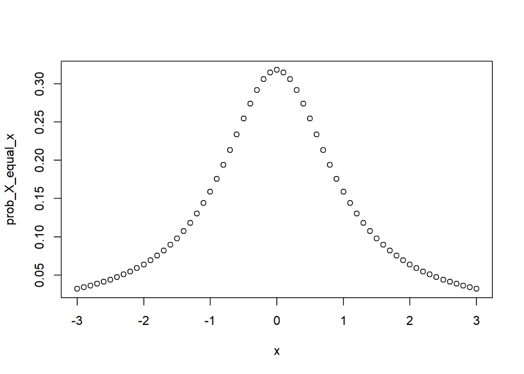

```r
x <- seq(-3, 3, 0.1)

# 확률밀도함수
prob_X_equal_x <-dt(x, df=1)
plot(x, prob_X_equal_x)
```

```r
# 상위 2.5% 에 해당하는 분위수 찾기
qt(1-0.025, df=10)
```

```
## [1] 2.228139
```

## 분포 탐색

미국 Yellowstone 국립공원내의 Old Faithful의 간헐온천(geyser) 분출시간(분)과 분출간 대기시간

```r
# datasets 패키지의 데이터
data(package='datasets')
# faithful                        Old Faithful Geyser Data

str(faithful)
```

```
## 'data.frame':    272 obs. of  2 variables:
##  $ eruptions: num  3.6 1.8 3.33 2.28 4.53 ...
##  $ waiting  : num  79 54 74 62 85 55 88 85 51 85 ...
```

```r
attach(faithful)
# ls(faithful)
```

요약 통계량

```r
summary(eruptions)
```

```
##    Min. 1st Qu.  Median    Mean 3rd Qu.    Max.
##   1.600   2.163   4.000   3.488   4.454   5.100
```

```r
fivenum(eruptions) # 평균 제외
```

```
## [1] 1.6000 2.1585 4.0000 4.4585 5.1000
```

```r
# 줄기-잎 그림
stem(eruptions)
```

```
##
##   The decimal point is 1 digit(s) to the left of the |
##
##   16 | 070355555588
##   18 | 000022233333335577777777888822335777888
##   20 | 00002223378800035778
##   22 | 0002335578023578
##   24 | 00228
##   26 | 23
##   28 | 080
##   30 | 7
##   32 | 2337
##   34 | 250077
##   36 | 0000823577
##   38 | 2333335582225577
##   40 | 0000003357788888002233555577778
##   42 | 03335555778800233333555577778
##   44 | 02222335557780000000023333357778888
##   46 | 0000233357700000023578
##   48 | 00000022335800333
##   50 | 0370
```

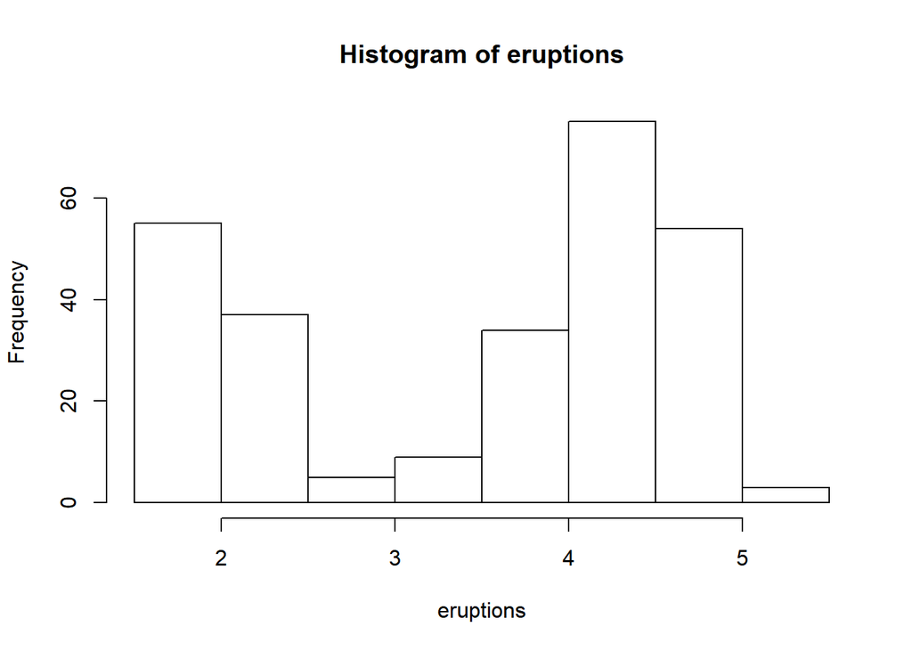

```r
# 히스토그램
hist(eruptions)
```

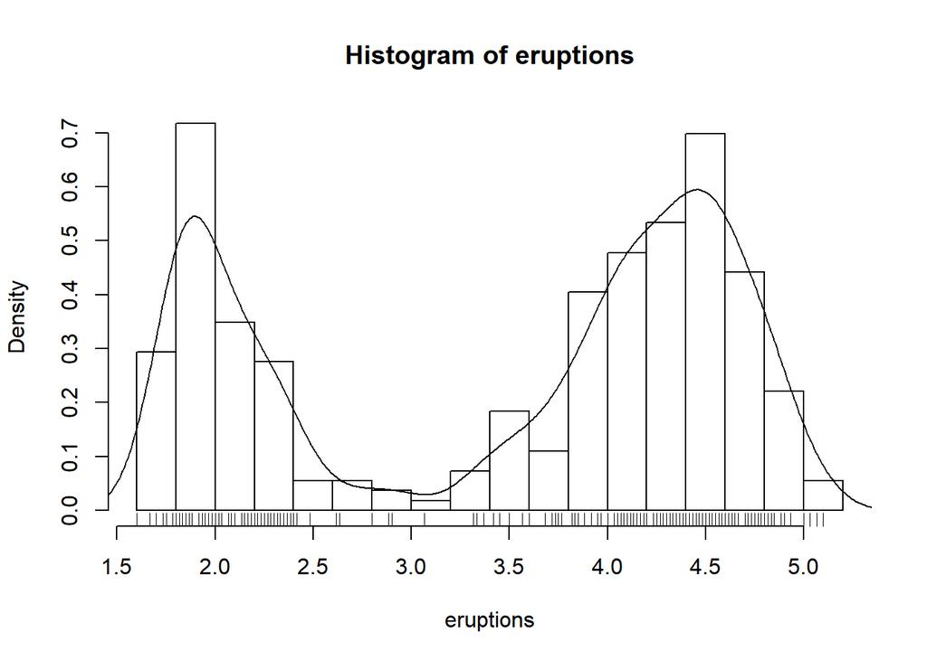

```r
hist(eruptions, seq(1.6, 5.2, 0.2), prob=TRUE)
lines(density(eruptions, bw = "SJ")) # 커널 밀도 추정량, bw는 띠너비 옵션
rug(eruptions, side=1)
```

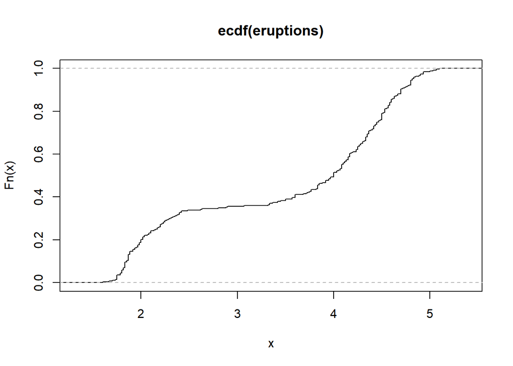

```r
# 경험 분포
plot(ecdf(eruptions), do.points=FALSE, verticals=TRUE) # 정규 분포와는 거리가 있음
```

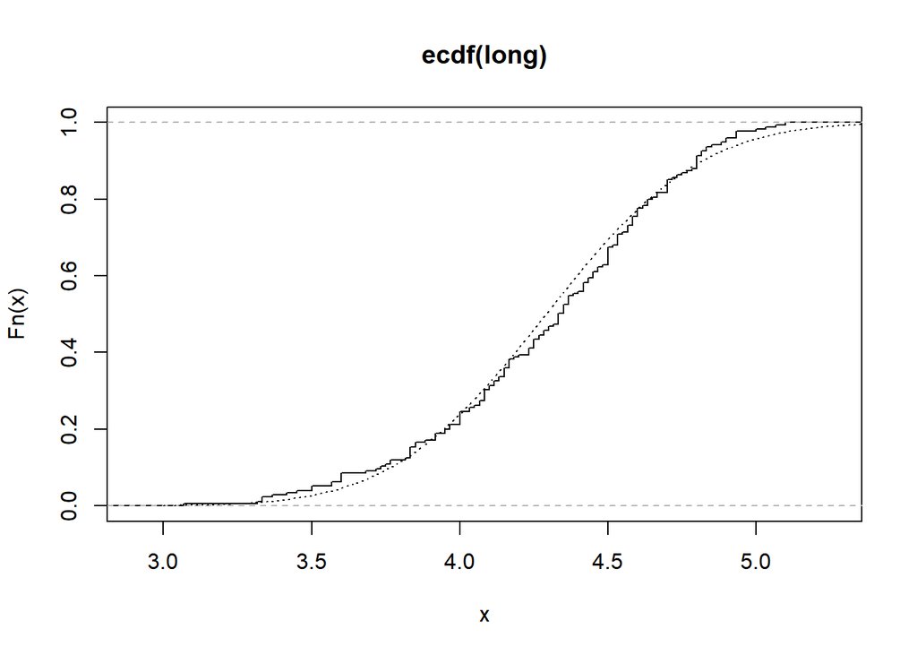

```r
# 일부 구간만 설정 후 정규분포와 비교
long <- eruptions[eruptions > 3]
plot(ecdf(long), do.points=FALSE, verticals=TRUE) # 정규 분포와는 거리가 있음
x <- seq(3, 5.4, 0.01)
lines(x, pnorm(x, mean=mean(long), sd=sqrt(var(long))), lty=3)
```

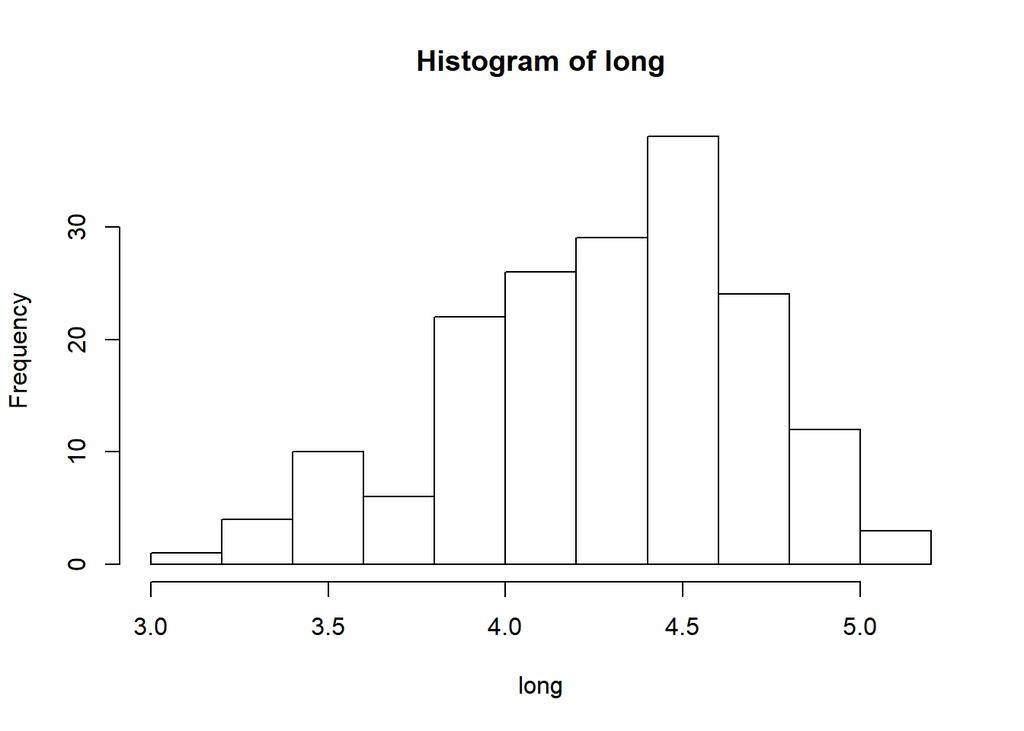

```r
# Q-Q 그림: 짧은 우측 꼬리
hist(long)
```

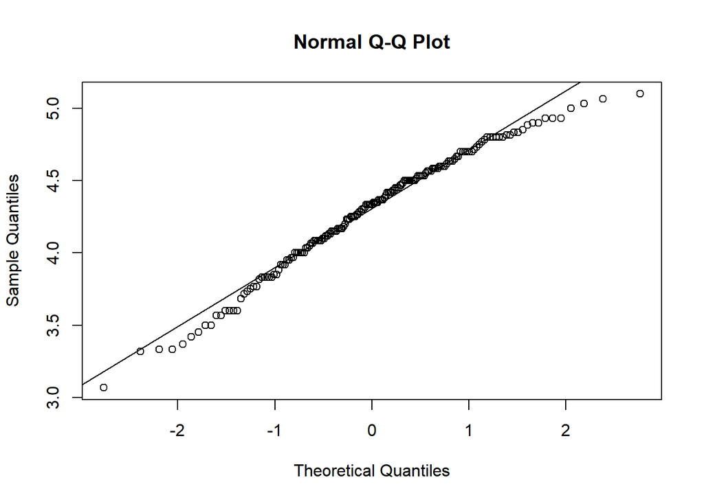

```r
qqnorm(long)
qqline(long)
```

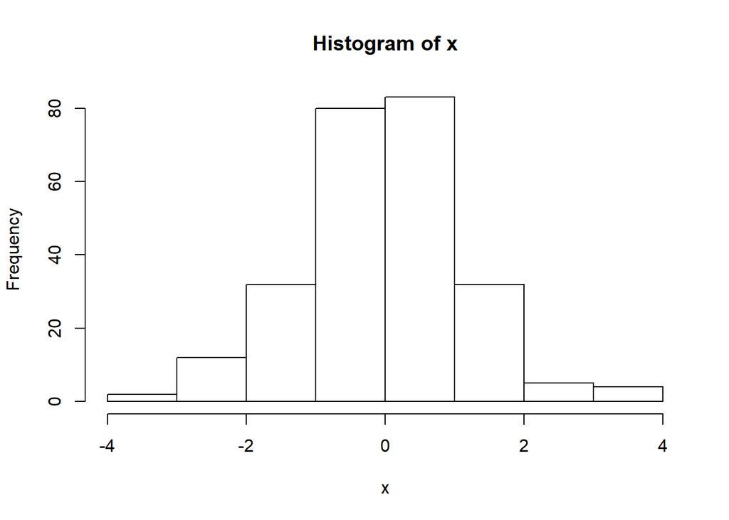

```r
# t 분포와 정규분포 비교: 긴 꼬리
x <- rt(250, df = 5)
hist(x)
```

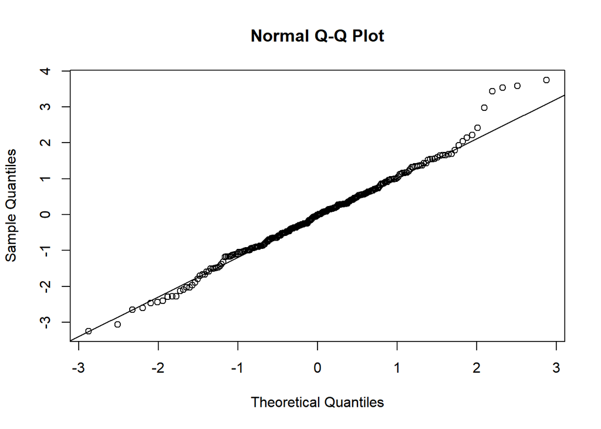

```r
qqnorm(x)
qqline(x)
```

```r
# 정규 분포 검정: Shapiro-Wilk test,  Kolmogorov-Smirnov test
shapiro.test(long) # 5% 유의수준에서 정규분포가 아님
```

```
##
##  Shapiro-Wilk normality test
##
## data:  long
## W = 0.97934, p-value = 0.01052
```

```r
ks.test(long, "pnorm", mean = mean(long), sd = sqrt(var(long)))
```

```
##
##  One-sample Kolmogorov-Smirnov test
##
## data:  long
## D = 0.066133, p-value = 0.4284
## alternative hypothesis: two-sided
```

## 2-표본 검정

$$H_0: \bar X_A = \bar X_B$$

```r
# 얼음융합 잠재열 데이터: 방법 A, 방법 B
A <- "79.98 80.04 80.02 80.04 80.03 80.03 80.04 79.97 80.05 80.03 80.02 80.00 80.02"
A <- as.numeric(strsplit(A, " ")[[1]])

B <- "80.02 79.94 79.98 79.97 79.97 80.03 79.95 79.97"
B <- as.numeric(strsplit(B, " ")[[1]])
```

```r
# 상자그림으로 평균의 차이 확인
summary(A)
```

```
##    Min. 1st Qu.  Median    Mean 3rd Qu.    Max.
##   79.97   80.02   80.03   80.02   80.04   80.05
```

```r
summary(B)
```

```
##    Min. 1st Qu.  Median    Mean 3rd Qu.    Max.
##   79.94   79.97   79.97   79.98   79.99   80.03
```

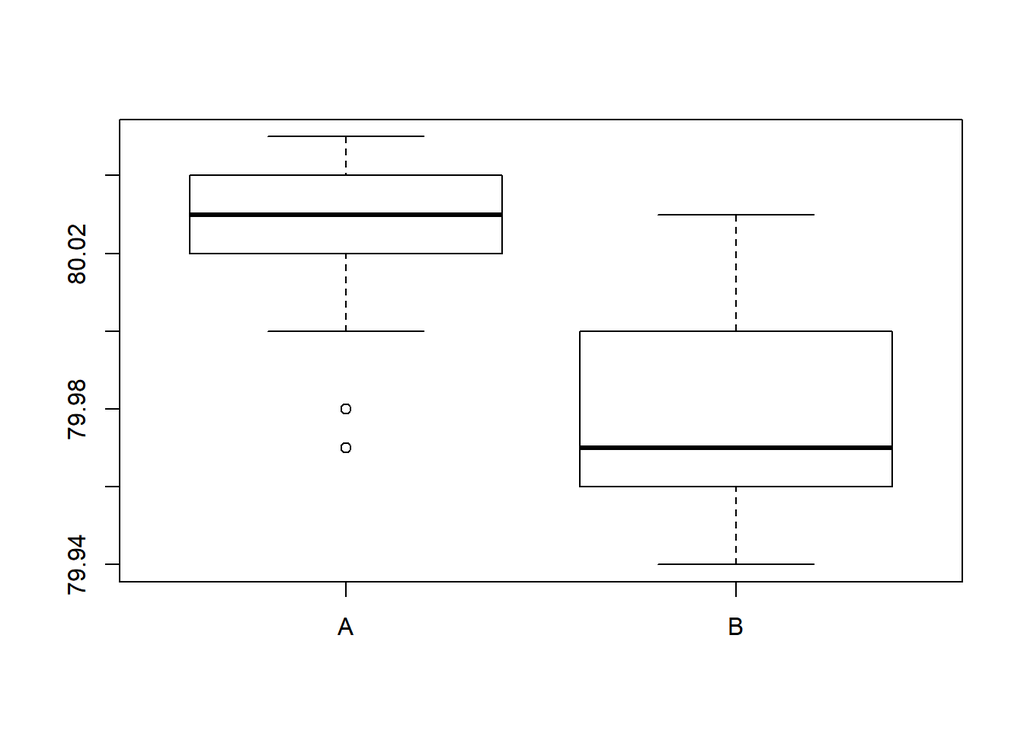

```r
boxplot(A, B, names=c('A', 'B'))
```

```r
# 2집단의 표본의 개수 확인
length(A)
```

```
## [1] 13
```

```r
length(B)
```

```
## [1] 8
```

```r
# 등분산 가정이 없는 평균 동일여부 검정
t.test(A, B)
```

```
##
##  Welch Two Sample t-test
##
## data:  A and B
## t = 3.2499, df = 12.027, p-value = 0.006939
## alternative hypothesis: true difference in means is not equal to 0
## 95 percent confidence interval:
##  0.01385526 0.07018320
## sample estimates:
## mean of x mean of y
##  80.02077  79.97875
```

```r
# 등분산에 대한 검정
var.test(A, B)
```

```
##
##  F test to compare two variances
##
## data:  A and B
## F = 0.58374, num df = 12, denom df = 7, p-value = 0.3938
## alternative hypothesis: true ratio of variances is not equal to 1
## 95 percent confidence interval:
##  0.1251097 2.1052687
## sample estimates:
## ratio of variances
##          0.5837405
```

```r
# 등분산 가정
t.test(A, B, var.equal=TRUE)
```

```
##
##  Two Sample t-test
##
## data:  A and B
## t = 3.4722, df = 19, p-value = 0.002551
## alternative hypothesis: true difference in means is not equal to 0
## 95 percent confidence interval:
##  0.01669058 0.06734788
## sample estimates:
## mean of x mean of y
##  80.02077  79.97875
```

```r
# 정규 가정 없는 비모수 검정
wilcox.test(A, B)
```

```
##
##  Wilcoxon rank sum test with continuity correction
##
## data:  A and B
## W = 89, p-value = 0.007497
## alternative hypothesis: true location shift is not equal to 0
```

$$KS \enspace statistic: D_{n,m}(x) = sup_{x}|F_n(x)-Fm(x)| \\
F_n(x)= {1 \over n} \sum_{i=1}^n 1_{X_i \le x} \\
critical \enspace region: D_{n,m}(x) > c(\alpha)\sqrt{(n+m) \over nm} \\
c(\alpha) = \sqrt{{-1 \over 2 }ln(\alpha )}$$

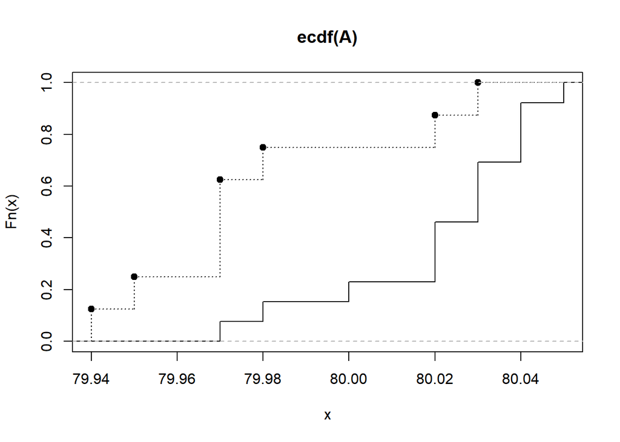

```r
# 분포 동일성 여부에 대하여 경험분포로부터 확인
plot(ecdf(A), do.points=FALSE, verticals=TRUE, xlim=range(A, B))
plot(ecdf(B), do.points=T, verticals=TRUE, lty=3, add=TRUE)
```

```r
ks.test(A, B)
```

```
##
##  Two-sample Kolmogorov-Smirnov test
##
## data:  A and B
## D = 0.59615, p-value = 0.05919
## alternative hypothesis: two-sided
```

```r
m= length(A)
n = length(B)
alpha = 0.025
c_alpha = sqrt(-0.5*log(alpha))
d_alpha = c_alpha*sqrt((m+n)/(m*n))
```

# 그룹화, 반복, 조건 실행

## 조건문

### if 문

```r
# 기본 형식
if (2 %in% c(1, 2,3)) print(TRUE) else print(FALSE)
```

```
## [1] TRUE
```

```r
# 단락(short-circuit)
if (4 %in% c(1, 2,3) && 3 %in% c(1,2,3)) print(TRUE) else print(FALSE)
```

```
## [1] FALSE
```